# DAND_P4_Brendan_Schell

# Univariate Plots Section

Determining the number of items and summary information about the dataset:

```
## [1] 1599
```

```
##        X          fixed.acidity   volatile.acidity  citric.acid
##  Min.   :   1.0   Min.   : 4.60   Min.   :0.1200   Min.   :0.000
##  1st Qu.: 400.5   1st Qu.: 7.10   1st Qu.:0.3900   1st Qu.:0.090
##  Median : 800.0   Median : 7.90   Median :0.5200   Median :0.260
##  Mean   : 800.0   Mean   : 8.32   Mean   :0.5278   Mean   :0.271
##  3rd Qu.:1199.5   3rd Qu.: 9.20   3rd Qu.:0.6400   3rd Qu.:0.420
##  Max.   :1599.0   Max.   :15.90   Max.   :1.5800   Max.   :1.000
##  residual.sugar     chlorides       free.sulfur.dioxide
##  Min.   : 0.900   Min.   :0.01200   Min.   : 1.00
##  1st Qu.: 1.900   1st Qu.:0.07000   1st Qu.: 7.00
##  Median : 2.200   Median :0.07900   Median :14.00
##  Mean   : 2.539   Mean   :0.08747   Mean   :15.87
##  3rd Qu.: 2.600   3rd Qu.:0.09000   3rd Qu.:21.00
##  Max.   :15.500   Max.   :0.61100   Max.   :72.00
##  total.sulfur.dioxide    density             pH          sulphates
##  Min.   :  6.00       Min.   :0.9901   Min.   :2.740   Min.   :0.3300
##  1st Qu.: 22.00       1st Qu.:0.9956   1st Qu.:3.210   1st Qu.:0.5500
##  Median : 38.00       Median :0.9968   Median :3.310   Median :0.6200
##  Mean   : 46.47       Mean   :0.9967   Mean   :3.311   Mean   :0.6581
##  3rd Qu.: 62.00       3rd Qu.:0.9978   3rd Qu.:3.400   3rd Qu.:0.7300
##  Max.   :289.00       Max.   :1.0037   Max.   :4.010   Max.   :2.0000
##     alcohol         quality
##  Min.   : 8.40   Min.   :3.000
##  1st Qu.: 9.50   1st Qu.:5.000
##  Median :10.20   Median :6.000
##  Mean   :10.42   Mean   :5.636
##  3rd Qu.:11.10   3rd Qu.:6.000
##  Max.   :14.90   Max.   :8.000
```

From the summary, it can be seen that there are 13 variables, all of which are numerical. X is simply the row number and is not useful for analysis purposes. The quality data uses discrete integers to denote the quality of the wine whereas others are based on measured property values.

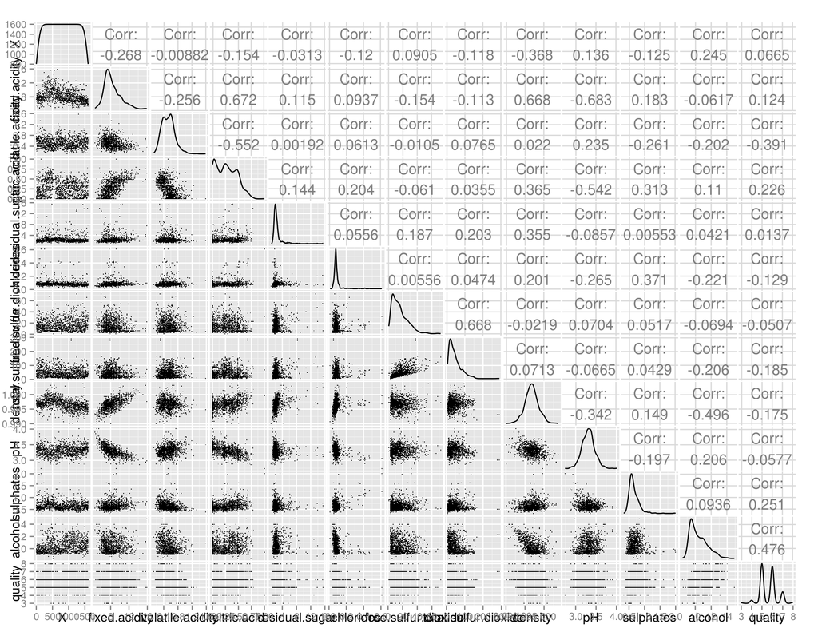

Based on the ggpairs output, the five strongest correlations with quality are alcohol,volatile acidity,sulphates,citric acid, and total sulfur dioxide. With my univariate and bivariate analyses, I only intend to look at the factors that affect quality of the wine.

The data was subset to only contain the top five variables with the strongest correlation to quality.

```
##    Min. 1st Qu.  Median    Mean 3rd Qu.    Max.
##    8.40    9.50   10.20   10.42   11.10   14.90
```

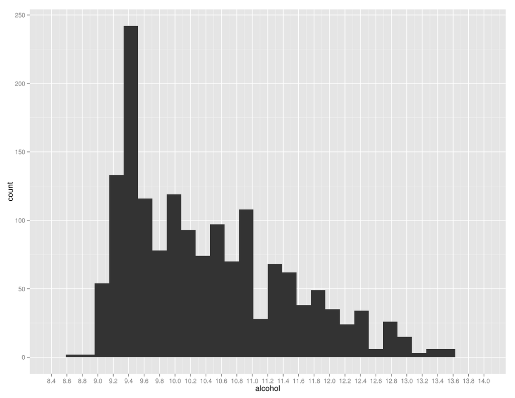

```
##    Min. 1st Qu.  Median    Mean 3rd Qu.    Max.
##  0.1200  0.3900  0.5200  0.5278  0.6400  1.5800
```

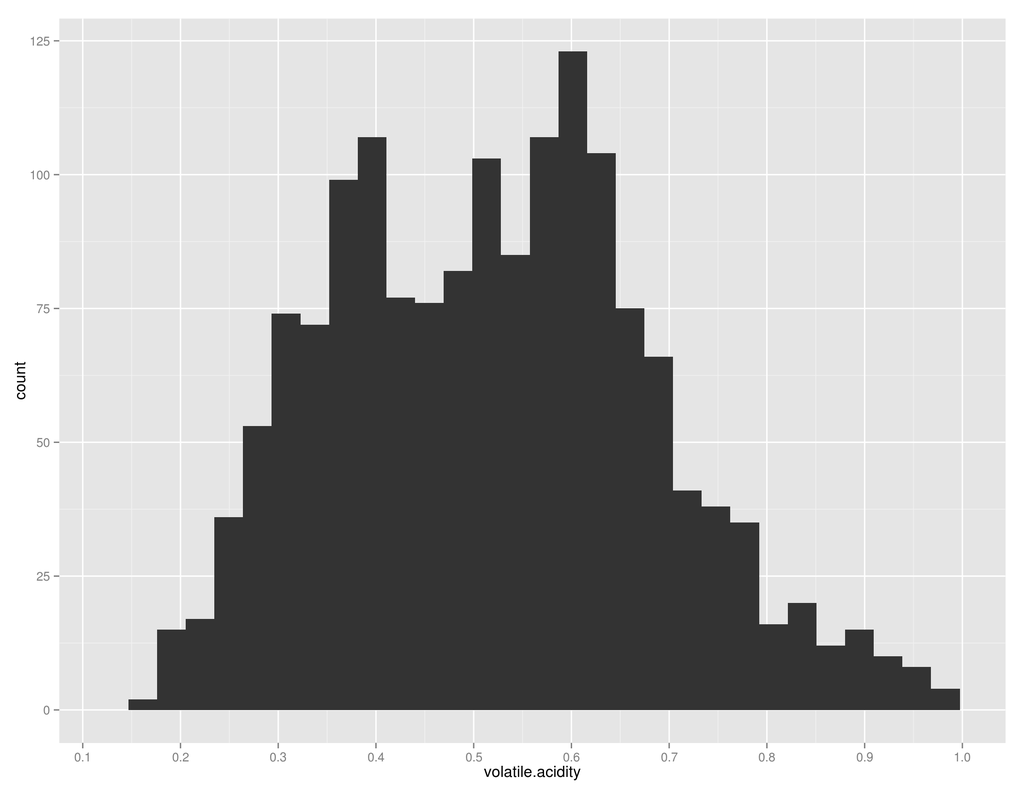

The volatile acidity data ranges between 0.12 and 1.58 with an almost bimodal distribution with peaks at ~0.35 and ~0.6. This data has some more extreme values on the higher end since the third quartile is 0.64, but the maximum is greater than twice this value. I would hypothesize that these higher end values contribute significantly to a decrease in quality.

```
##    Min. 1st Qu.  Median    Mean 3rd Qu.    Max.
##   0.000   0.090   0.260   0.271   0.420   1.000
```

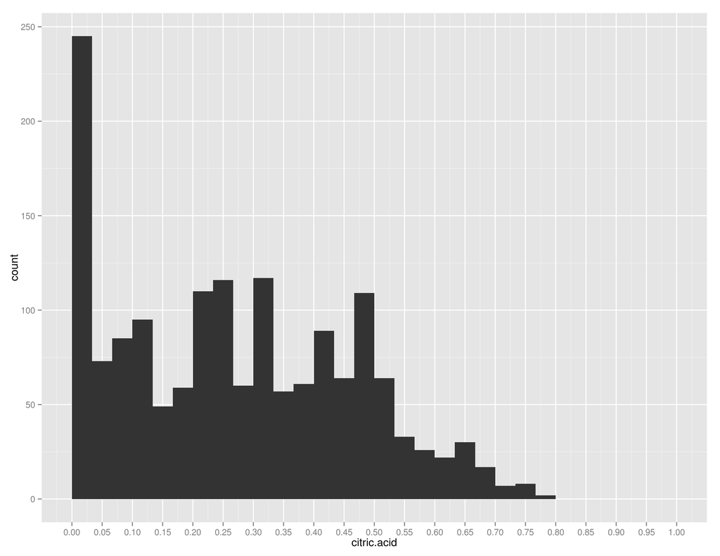

```
## [1] 132
```

The citric acid content ranges from 0 to 1, but a significant number of the samples seem to have no addition. Out of interest, I determined that 132 of the 1599 samples had no citric acid addition.

```
##    Min. 1st Qu.  Median    Mean 3rd Qu.    Max.
##  0.3300  0.5500  0.6200  0.6581  0.7300  2.0000
```

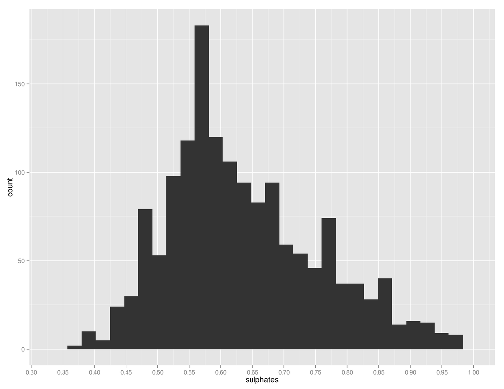

The sulphate content ranges from 0.33 to 2, but the vast majority of the data has a value less than 1 with the max of 2 demonstrating that there are significant outliers. From the histogram, the sulphate content seems to be normally distributed across the samples.

```
##    Min. 1st Qu.  Median    Mean 3rd Qu.    Max.
##    6.00   22.00   38.00   46.47   62.00  289.00
```

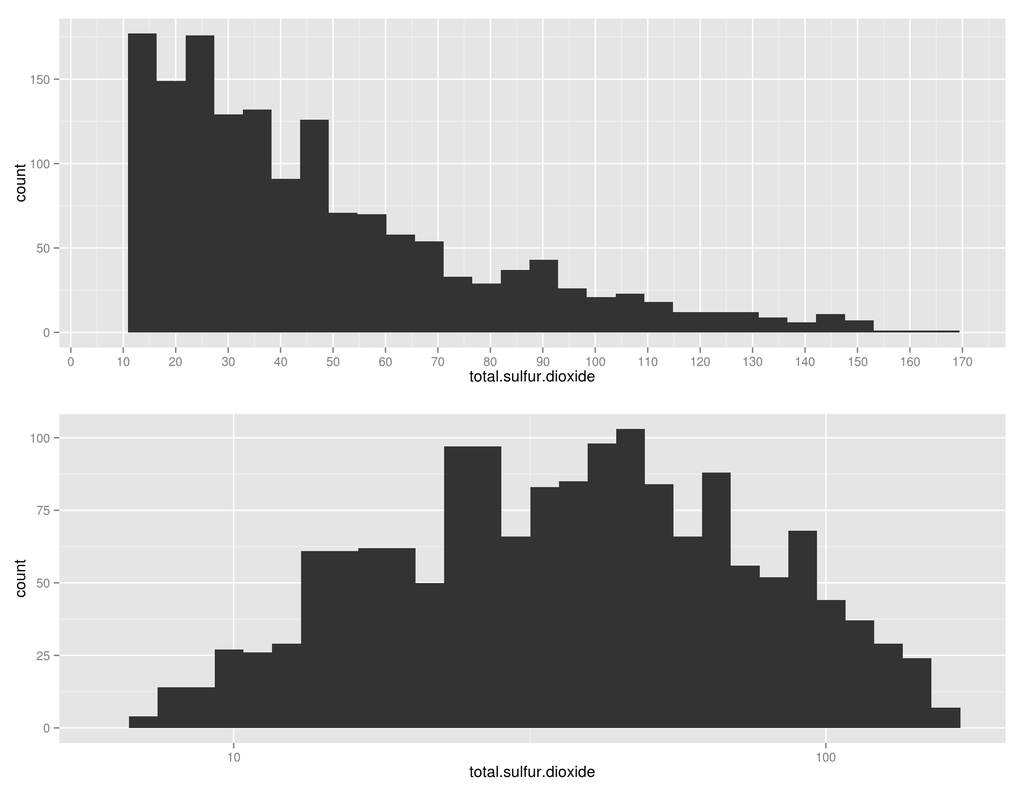

The total sulfur dioxide content ranges from 6 to 289, but seems to have a long-tailed distribution from the histogram. Plotting the histogram using a logarithimic x scale produces a much more normalized distribution.

```
##    Min. 1st Qu.  Median    Mean 3rd Qu.    Max.
##   3.000   5.000   6.000   5.636   6.000   8.000
```

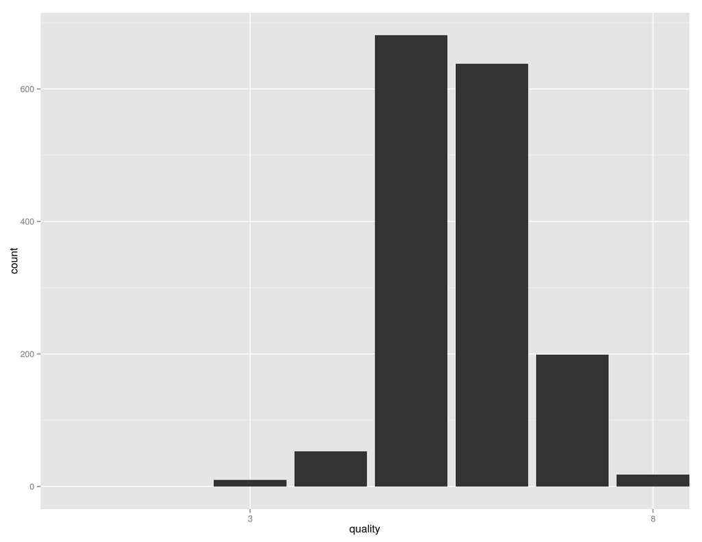

The quality rating ranges from 3 to 8, with a median of 6. The third quartile values is also a six, indicating that less than a quarter of the samples received a rating of 7 or 8.

```
##    Min. 1st Qu.  Median    Mean 3rd Qu.    Max.
## 0.02273 0.25930 0.37500 0.38230 0.48480 0.85710
```

```
## [1] 0.1941134
```

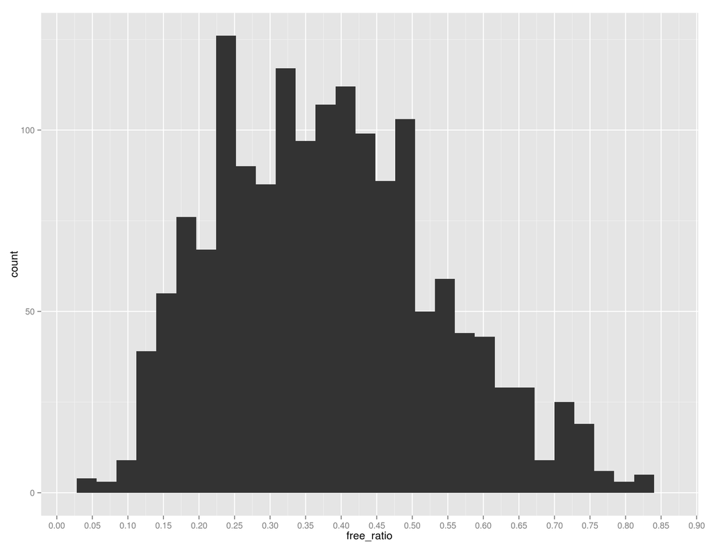

The variable free_ratio was created to indicate the proportion of sulphates that are free versus fixed. I’ve heard that this ratio is important to the quality of wines so I have examined the correlation and found it to be 0.194. This demonstrates a stronger correlation than the total sulfur dioxide quantity that was previously examined.

# Univariate Analysis

## What is the structure of your dataset?

The data is structured as 1599 observations of 11 measured variables of wine (alcohol, fixed.acidity, volatile.acidity, citric.acid, residual.sugar, chlorides, sulphates, free.sulfur.dioxide, total.sulfur.dioxide, pH, density), along with a quality rating variable and a variable, x, that contains the observation number.

All measured variables are numeric and both the quality and x variable are discrete integer values.

General Observations:

## What is/are the main feature(s) of interest in your dataset?

The main feature of interest is the quality of the wine and how the different chemical properties of the wine result in this quality value.

## What other features in the dataset do you think will help support your investigation into your feature(s) of interest?

The other features of interest in the dataset were chosen to be the five chemical properties with the greatest correlation to the quality rating of the wine. These five variables (alcohol, volatile.acidity, citric.acid, sulphates, total.sulfur.dioxide, quality) were placed along with the quality variable into a subset titled wines_small.

## Of the features you investigated, were there any unusual distributions? Did you perform any operations on the data to tidy, adjust, or change the form of the data? If so, why did you do this?

I noticed that the total sulfur dioxide content had a right-skewed distribution so I performed a log transformation on the plot to normalize the data.

# Bivariate Plots Section

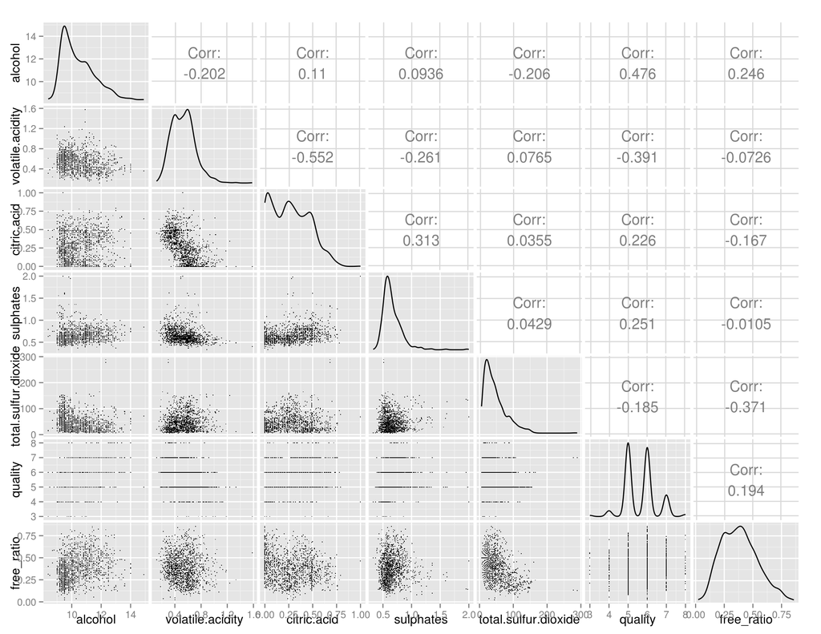

I am mostly interested in observing the effects of these variables on the quality of the wine, so I will plot these variables in greater detail to examine the link. As well, since I am not very concerned between the quality difference of a 3 vs a 4, a 5 vs a 6, or a 7 vs an 8, I will bin these into three categories (poor, fair and good)

```
## [1] 0.4761663
```

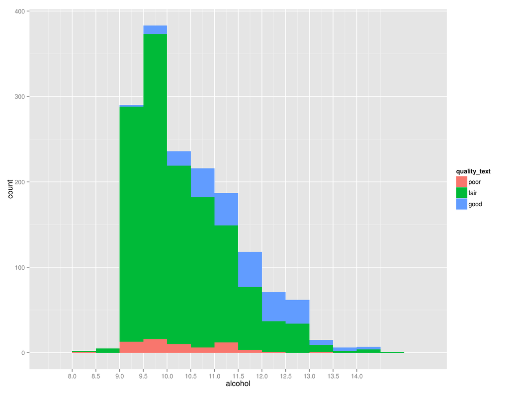

It can be seen that for the alcohol content, very few good wines exist below ~9.5% and very few poor wines past ~12%. Along with the correlation of 0.476, this indicates an increase in quality with higher alcohol wines.

```
## [1] -0.3905578
```

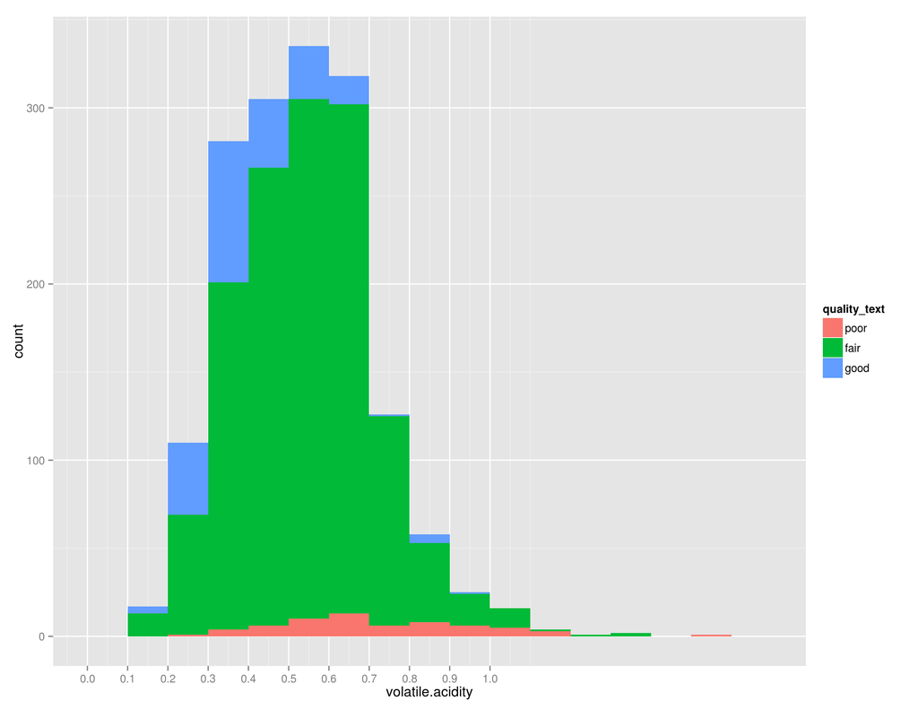

For the volatile acidity, a negligible amount of good wines exist after a volatile acidity of ~ 0.7. This explains the negative correlation coefficient of -0.391.

```
##    Min. 1st Qu.  Median    Mean 3rd Qu.    Max.
##   0.000   0.090   0.260   0.271   0.420   1.000
```

```
## [1] 0.2263725
```

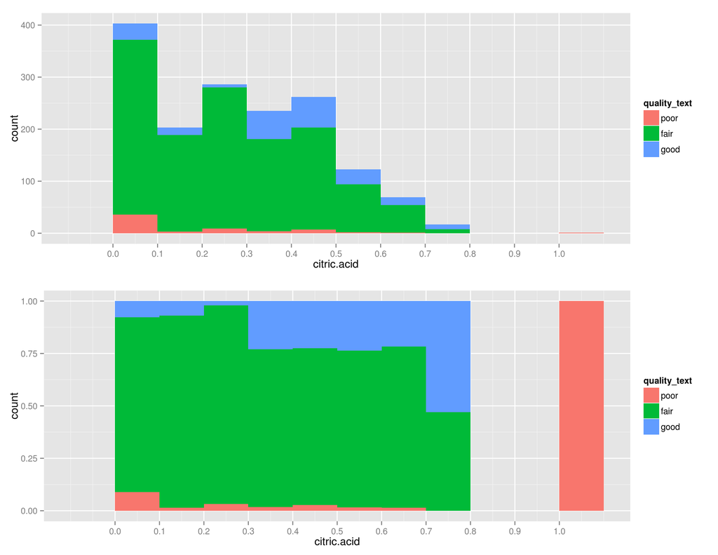

From the initial histogram of citric acid based on quality, there is no discernable pattern using the count. When a relative frequency histogram is done however, it can be seen that the proportion of good to fair quality wines increases with the citric acid content. Since there are significantly more samples at the lower end of citric acid content, it is difficult to tell whether this is a true correlation or if it is biased by the sample distribution.

In the univariate plot section, I proposed that it might be interesting to look at those samples where there is no citric acid addition at all and how that would affect the quality. Based on the above plots, I no longer think this would be interesting since it does not seem as though there is any interesting quality relationship at the lower levels.

```
##    Min. 1st Qu.  Median    Mean 3rd Qu.    Max.
##  0.3300  0.5500  0.6200  0.6581  0.7300  2.0000
```

```
## [1] 0.2513971
```

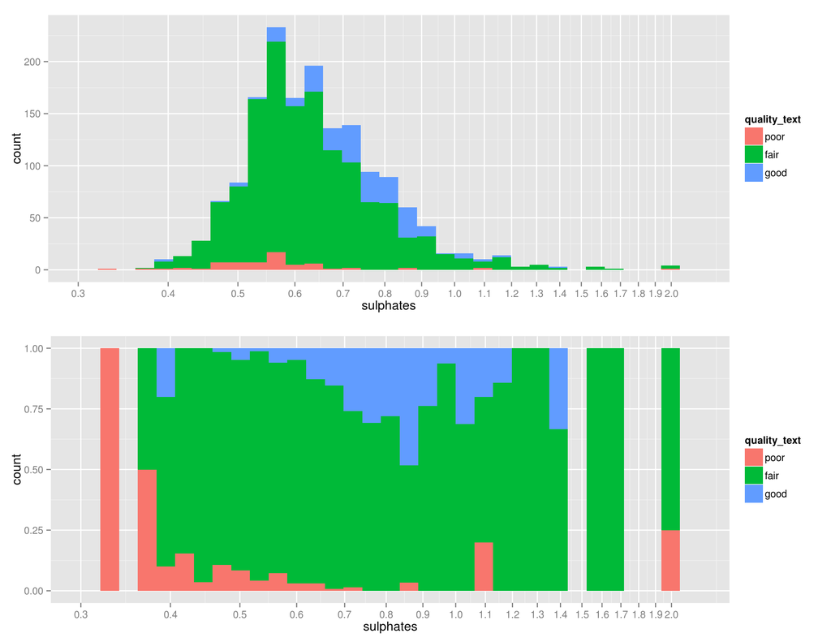

From the histogram of sulphates coloured by quality, the main point of interest is that there appears to be an almost parabolic distribution in the ratio of good to fair wine quality as the sulphate content increases logarithmically. That being said, there are many more samples at the lower end of the distribution which could unfairly form this conclusion.

```
##    Min. 1st Qu.  Median    Mean 3rd Qu.    Max.
##    6.00   22.00   38.00   46.47   62.00  289.00
```

```
## [1] -0.1851003
```

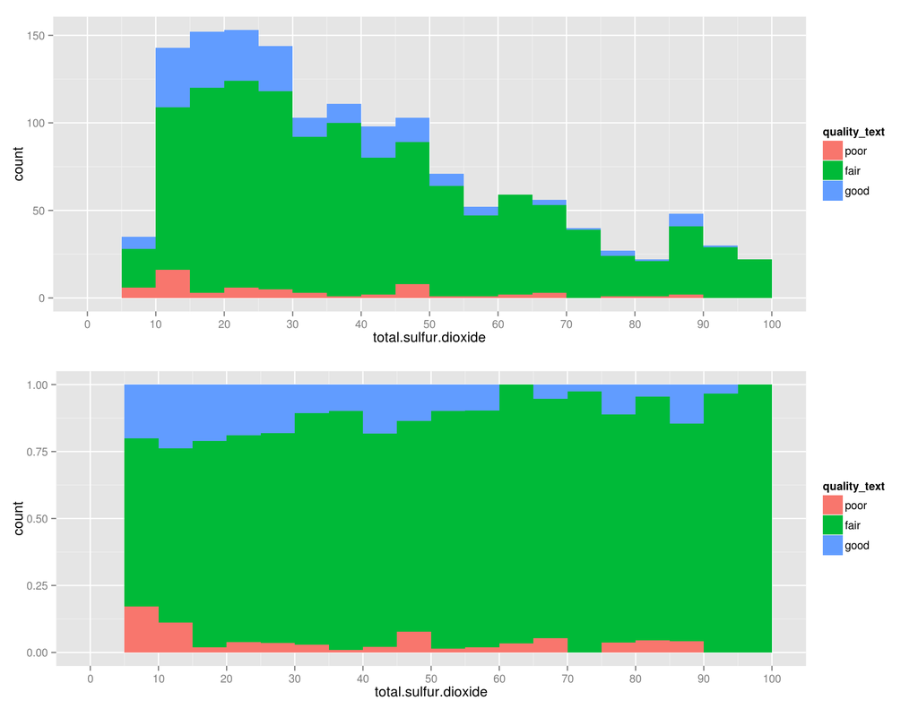

```
##    Min. 1st Qu.  Median    Mean 3rd Qu.    Max.
## 0.02273 0.25930 0.37500 0.38230 0.48480 0.85710
```

```
## [1] 0.1941134
```

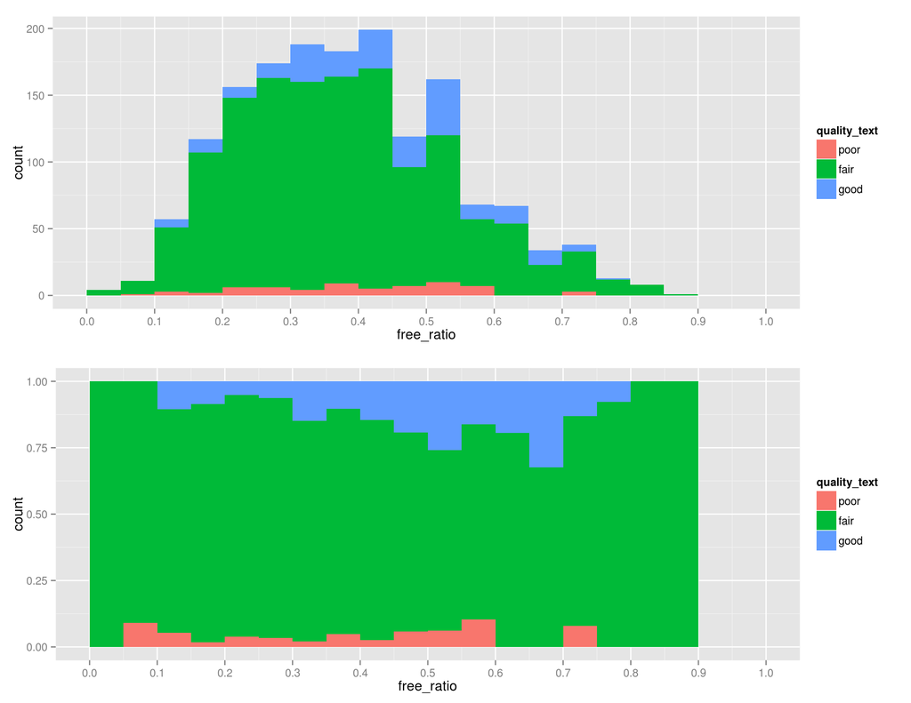

With a correlation coefficient of 0.194, it would be assumed that increasing the free ratio should increase the quality. From the relative histogram of the plot, the relationship looks more parabolic for producing good quality wines vs fair quality wines. This likely indicates that there is an optimum value for the free ratio.

```
## [1] -0.5524957
```

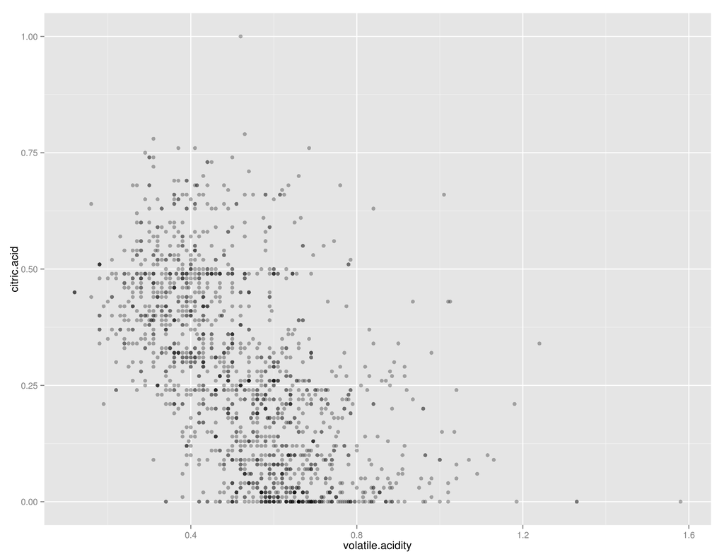

I figured it would be interesting to examine the relationship between the citric acid content and the volatile aciity. From the correlation coefficient of -0.55 and the plot, it suggests that there is a relatively strong negative correlation between the two variables. This suggests that there must be other acids in the wine and that at higher volatile acidity levels, these other acids are predominate.

# Bivariate Analysis

## Talk about some of the relationships you observed in this part of the investigation. How did the feature(s) of interest vary with other features in the dataset?

From the relationships in this part of the investigation, there are no strong correlations with the quality and any one variable. This indicates the complexity involved in how the different chemical factors of wine contribute to the taste. As well, because the quality ratings of the wines are subjective, I lumped the scores into three categories (3-4: Poor, 5-6: Fair, 7-8: Good) so that they could more easily be evaluated from the plots.

The alcohol content had a mostly linear relationship with higher alcohol content resulting in an increase in the quality of the wine.

The volatile acidity of the wine had a mostly linear relationship with lower volatile acidity resulting in an increase in the quality of the wine.

The citric acid content seems to contribute positively to the quality of the wine with more good and fair quality wines with greater citric acid content. Contrary to what was initially proposed, there does not seem to be any interesting behaviour in quality associated with the binary presence of citric acid.

The free ratio and sulphate content both seem to exhibit parabolic behaviour when it comes to the ratio of good/fair quality wines. If this is the case, then there should be an optimum presence of each that could be determined.

## What was the strongest relationship you found?

The strongest relationship I found related to the quality of the wine was the relationship between alcohol content and quality. From the data, it seems as though very few low alcohol percentage wines were considered to be good, while higher alcohol percentage wines tended to have proportionally higher good and fair quality wines. This raises an interesting question of whether the higher alcohol percentage masks the other qualities of the wine (leading tasters to believe it is a better quality wine than it is), or if it is a feature of the wine that makes it inherently taste better.

# Multivariate Plots Section

Since alcohol proved to be the greatest contributor to the quality of the wine, I will be exploring how each of the factors works in combination with alcohol to produce a better quality wine. I will not be exploring the total sulfur dioxide content since it seemed as though the correlation was more a result of the sample distribution rather than due to the factor itself.

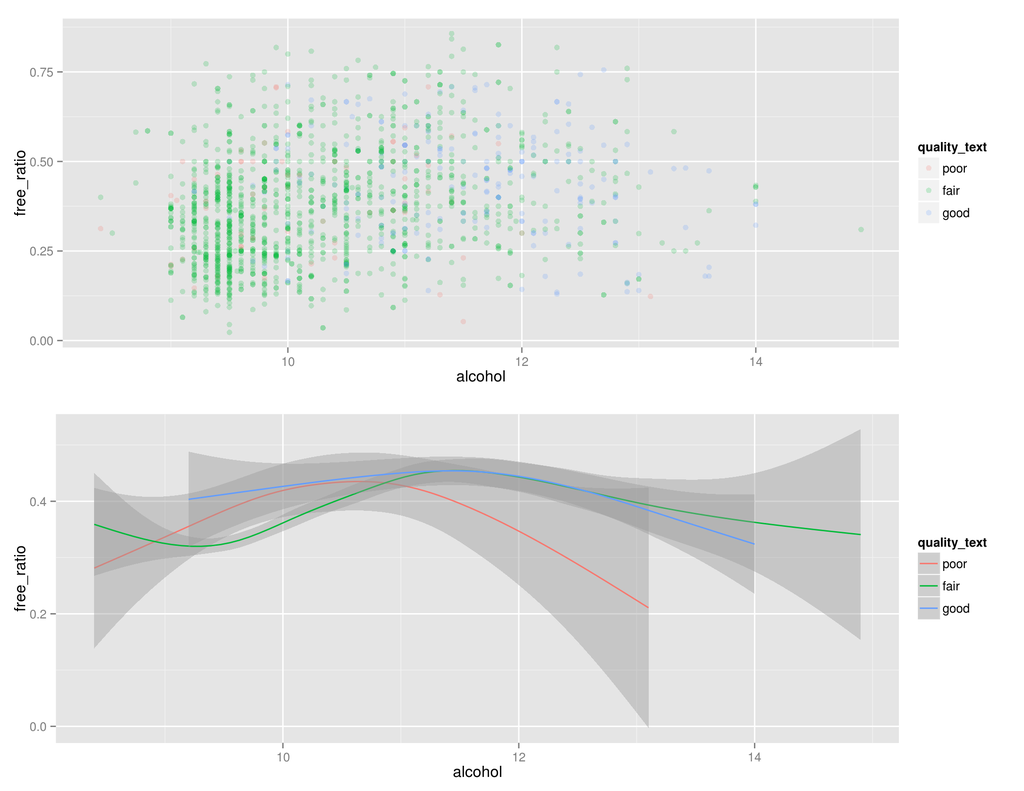

By observing how the free ratio and alcohol vary with eachother along with the quality, it can be seen that most of the samples have less than ~11% alcohol and free ratios less than 0.5. As well, at the higher alcohol percentages, it can be seen that the free ratio varies considerably, yet the vast majority of wines at alcohol percentages above 12 are either good or fair quality wines.

In the smoothed line plot, it can be seen that good quality wines vary considerably across the alcohol content, but very little across the free ratio value. For fair and poor quality wines, there is considerably more variation in the free ratio over similar ranges of alcohol content. As well, parabolic behaviour seems to exist for both the good and poor quality wines.

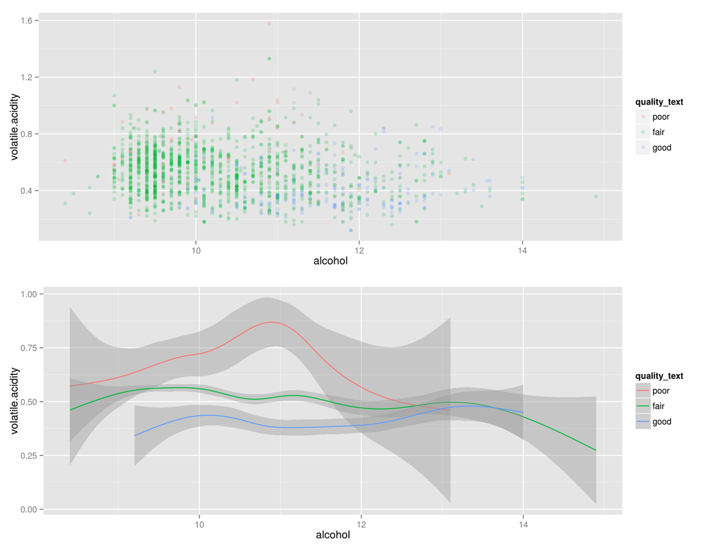

The data seems to be primarily clustered around volatile acidity values less than 0.8. It can be seen in the smoothed line plot that for alcohol values less than ~11.5, there are almost three distinct groups of volatile acidity. After an alcohol percentage of around 12, the volatile acidity does not seem to matter.

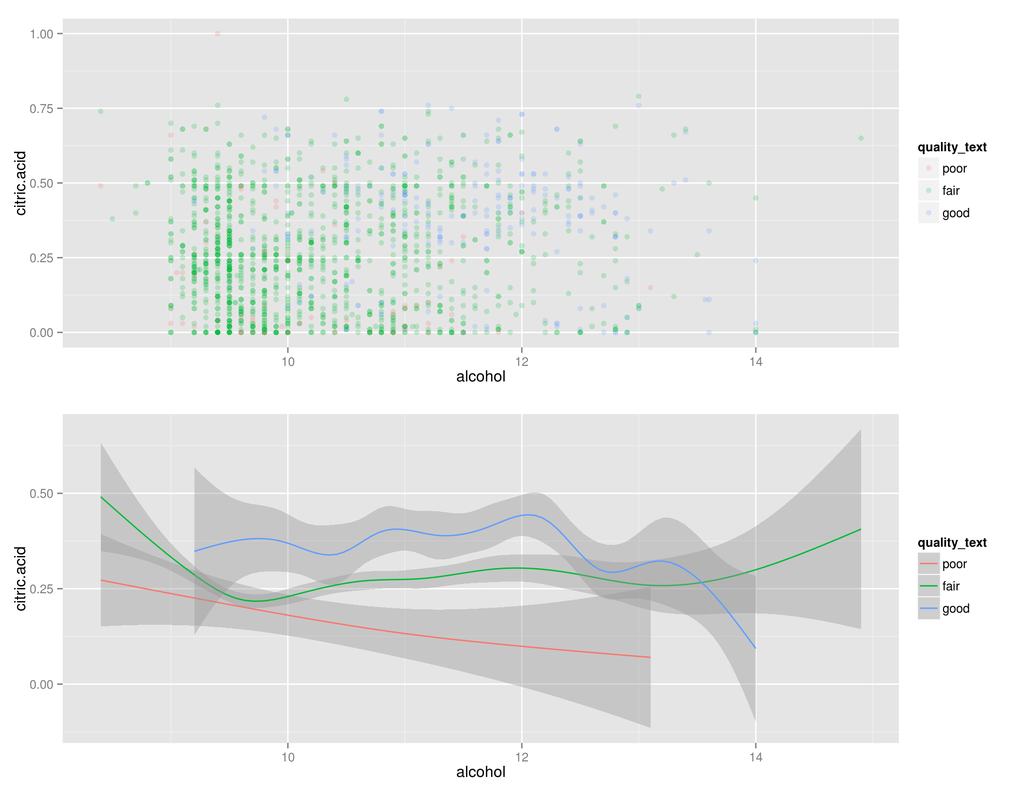

It seems as though increasing the citric acid content improves the quality up until an alcohol percentage of around 13% where the alcohol content seems to be more dominant in affecting the quality.

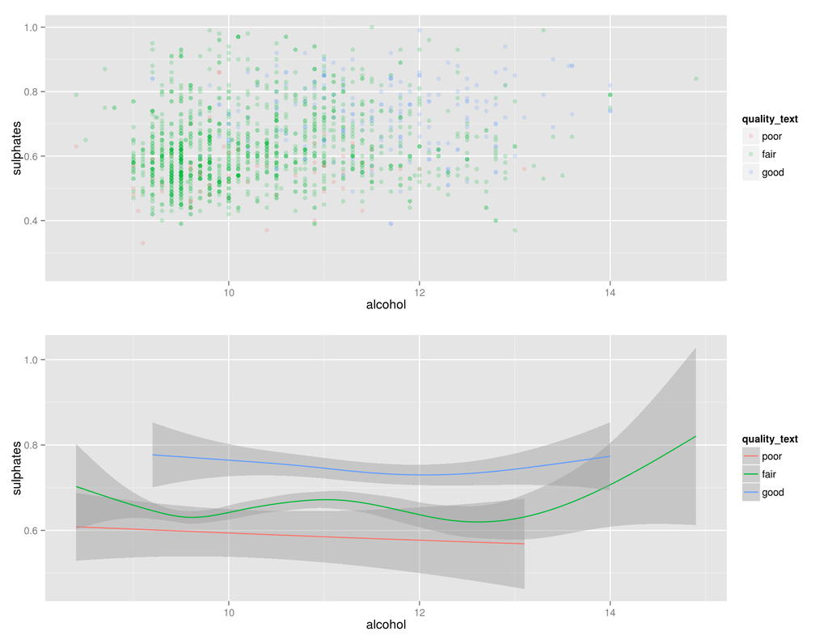

It seems as though increasing the sulphate content universally improves the quality of the wine across all alcohol values. It seems as though there is an optimum value between 0.7 and 0.9 for the sulphate content.

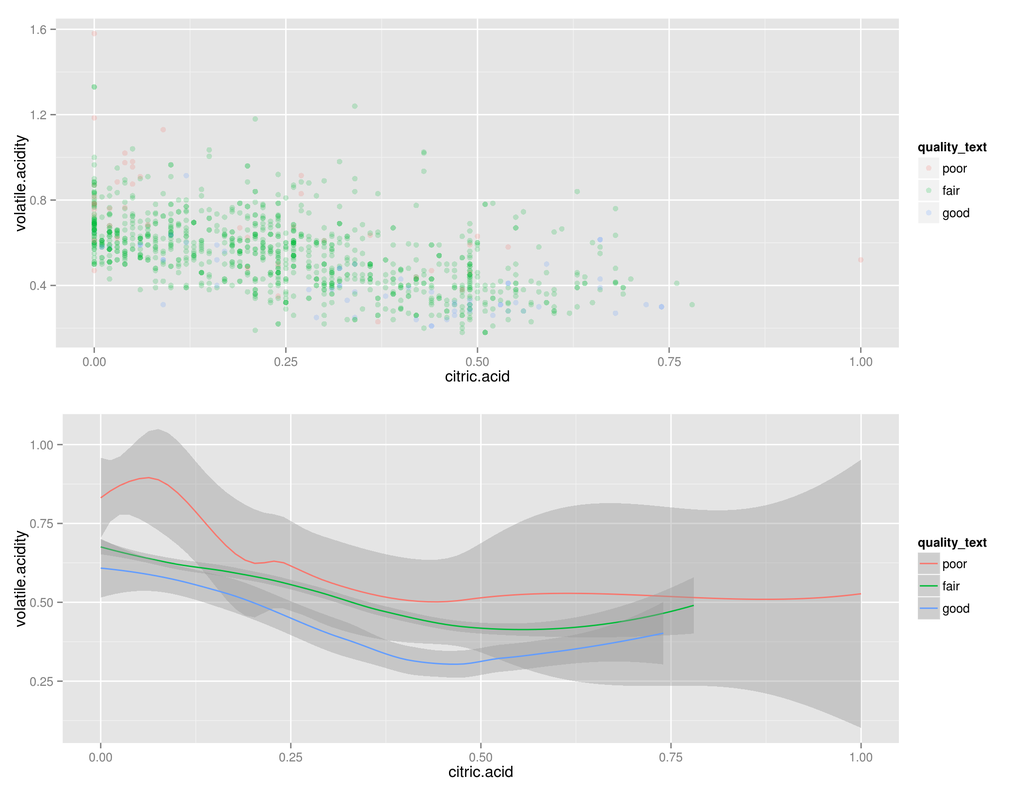

Keeping the alcohol range within 9% to 11%, it seems that optimal quality is achieved by reducing the volatile acidity and citric acid content to below 0.6 and 0.75 respectively.

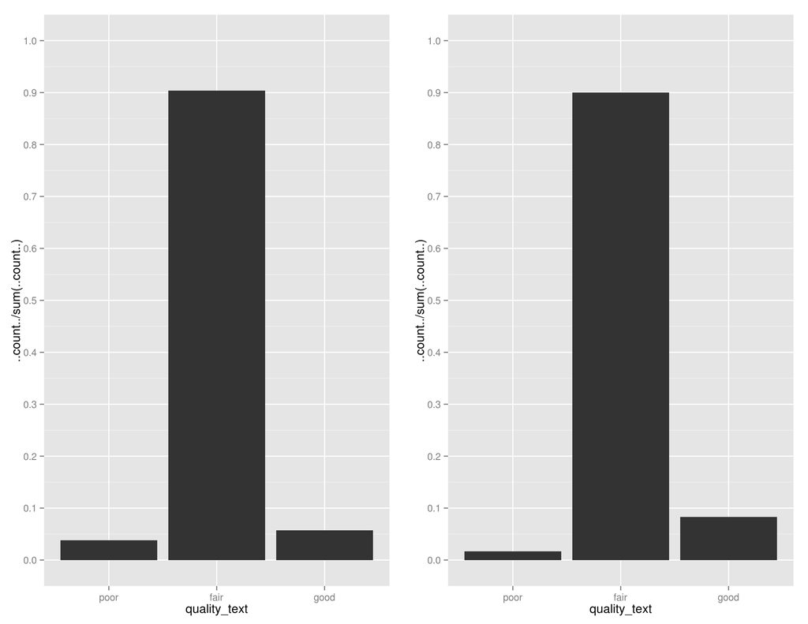

Keeping the alcohol content within the same range of 9% to 11% and using the values that were determined to be optimal for citric acid and volatile acidity improved the proportion of good quality wines and reduced the proportion of poor quality wines.

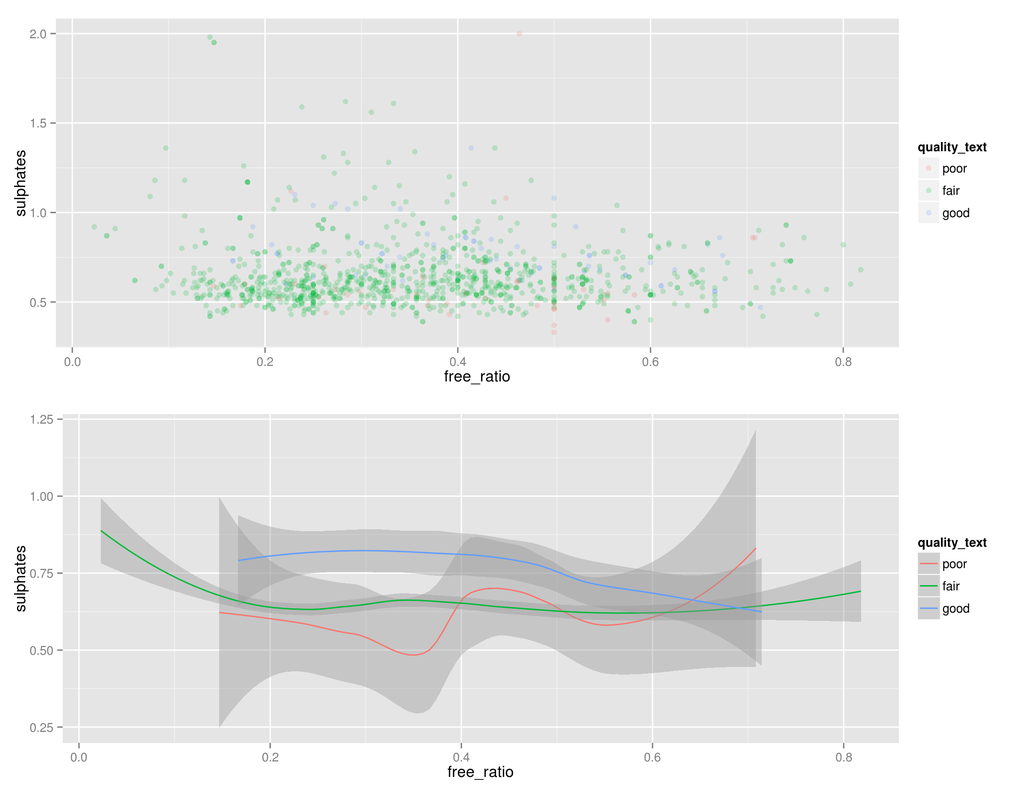

Keeping the alcohol content in the same range of 9 to 11%, but looking at only sulphates and the free_ratio, it does not seem as though the free ratio plays much of a role in determining good quality wines since it varies considerably across the samples for all qualities of wine. To look at improving the ratio from the previous plots, it might be interesting to look at restricting the free ratio to below 0.4 and the sulphate content to above 0.7 since this appears like a range where more good quality wines exist (though also some poor quality wines as well).

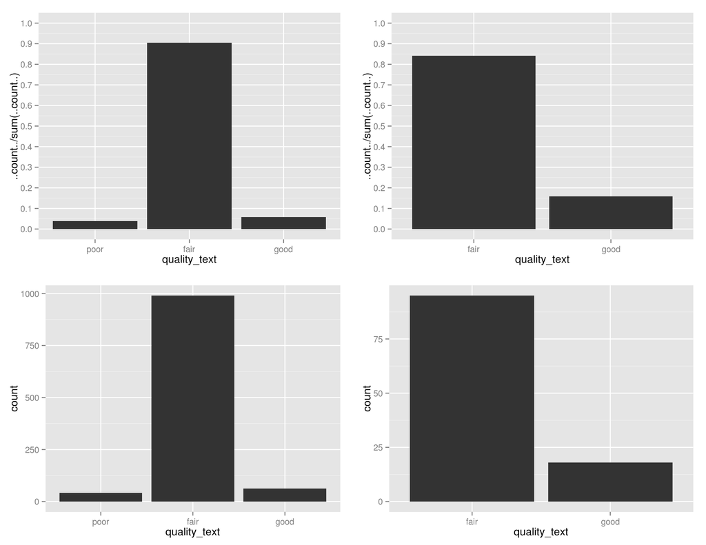

By restricting the values for the volatile acidity, citric acid, sulphates, and free ratio, the sample was restricted to only fair and good quality wines. Though by doing this, it has significantly reduced the sample size which could lead to issues such as overfitting.

```
##
## Calls:
## m1: lm(formula = I(quality_num) ~ I(alcohol), data = wines_small)
## m2: lm(formula = I(quality_num) ~ I(alcohol) + volatile.acidity,
##     data = wines_small)
## m3: lm(formula = I(quality_num) ~ I(alcohol) + volatile.acidity +
##     citric.acid, data = wines_small)
## m4: lm(formula = I(quality_num) ~ I(alcohol) + volatile.acidity +
##     citric.acid + sulphates, data = wines_small)
## m5: lm(formula = I(quality_num) ~ I(alcohol) + volatile.acidity +
##     citric.acid + sulphates + free_ratio, data = wines_small)
##
## ===================================================================
##                      m1        m2        m3        m4        m5
## -------------------------------------------------------------------
## (Intercept)        1.875***  3.095***  3.055***  2.646***  2.577***
##                   (0.175)   (0.184)   (0.194)   (0.201)   (0.201)
## I(alcohol)         0.361***  0.314***  0.314***  0.309***  0.294***
##                   (0.017)   (0.016)   (0.016)   (0.016)   (0.016)
## volatile.acidity            -1.384*** -1.343*** -1.265*** -1.196***
##                             (0.095)   (0.114)   (0.113)   (0.114)
## citric.acid                            0.068    -0.079     0.023
##                                       (0.103)   (0.104)   (0.107)
## sulphates                                        0.696***  0.691***
##                                                 (0.103)   (0.103)
## free_ratio                                                 0.426***
##                                                           (0.113)
## -------------------------------------------------------------------
## R-squared             0.227     0.317     0.317     0.336     0.342
## adj. R-squared        0.226     0.316     0.316     0.334     0.340
## sigma                 0.710     0.668     0.668     0.659     0.656
## F                   468.267   370.379   246.976   201.777   165.587
## p                     0.000     0.000     0.000     0.000     0.000
## Log-likelihood    -1721.057 -1621.814 -1621.596 -1599.093 -1592.016
## Deviance            805.870   711.796   711.603   691.852   685.755
## AIC                3448.114  3251.628  3253.192  3210.186  3198.032
## BIC                3464.245  3273.136  3280.078  3242.448  3235.671
## N                  1599      1599      1599      1599      1599
## ===================================================================
```

# Multivariate Analysis

## Talk about some of the relationships you observed in this part of the investigation. Were there features that strengthened each other in terms of looking at your feature(s) of interest?

In this part of the investigation, I explored other factors in the reduced dataset (wines_small) versus alcohol and coloured the plots by the quality of the wines. I also examined how the smoothed line data was distributed for each of the three quality levels. For the sulphate and citric.acid variables , increasing them seemed to produce better quality wines in general. For the free ratio and volatile acidity variables, there seemed to be optimum values to use to produce good / fair quality wines for different alcohol percentages. It seemed that with each of these four variables, they could be used in conjunction with the alcohol percentage to produce the feature of interest, which is a good quality wine.

I then narrowed the investigation to an alcohol range of 9% to 11% (where most of the samples resided) and determined rough conditional values to increase the ratio of good and fair quality wines to poor quality wines. These conditional values were:

- Volatile Acidity : < 0.6
- Citric Acid: < 0.75
- Sulphates: > 0.7
- Free Ratio: < 0.4

When the dataset was subset to include only these conditions, the result was the elimination of poor quality wines altogether, and an increased proportion of good quality to fair quality wines from less than 10% to close to 20%.

## Were there any interesting or surprising interactions between features?

One interesting interaction that I found was that when only alcohol and citric acid were plotted to see how they affect the quality for all samples, it seemed as though increasing the citric acid content would universally improve the quality of the wine. However, when the citric acid content was compared against the volatile acidity to see how it affects quality, it showed that reducing the citric acid content to below 0.75 would actually be optimal for removing poor wines with alcohol percentages between 9% and 11%.

## OPTIONAL: Did you create any models with your dataset? Discuss the strengths and limitations of your model.

I did create a linear model using the variables of volatile acidity, citric acid, sulphates, alcohol, and the free ratio. The strength of this model is that using only a few measurable qualities of the wine, you could obtain a prediction for the quality rating. As a result, it is a relatively simple method of determining if a wine will be good or not based on only a few input variables.

Since the wines dataset was limited only to red Vinha Verde wines, this model is likely not applicable to the vast majority of red wines. As well, only a few of the variables in the wines dataset were actually considered in this model. As a result, the model does not have much value in predicting wine quality (r^2 value of 0.342) as it does not account for most of the variation in the wines dataset. This linear model is also overfit to this dataset alone and likely does not apply numerically to other datasets unless they are from the same vineyard in the same conditions. Lastly, when analysis was performed to choose these variables, the wine qualities were binned into three categories (good, fair, poor). In this numerical model, the critic rating of 1 to 10 is calculated which is much more arbitrary and harder to interpret. A better model would probably be obtained by simplifying the quality numerically into a rating of 1 to 3 (where one is good, 2 fair, 3 poor).

# Final Plots and Summary

## Plot One

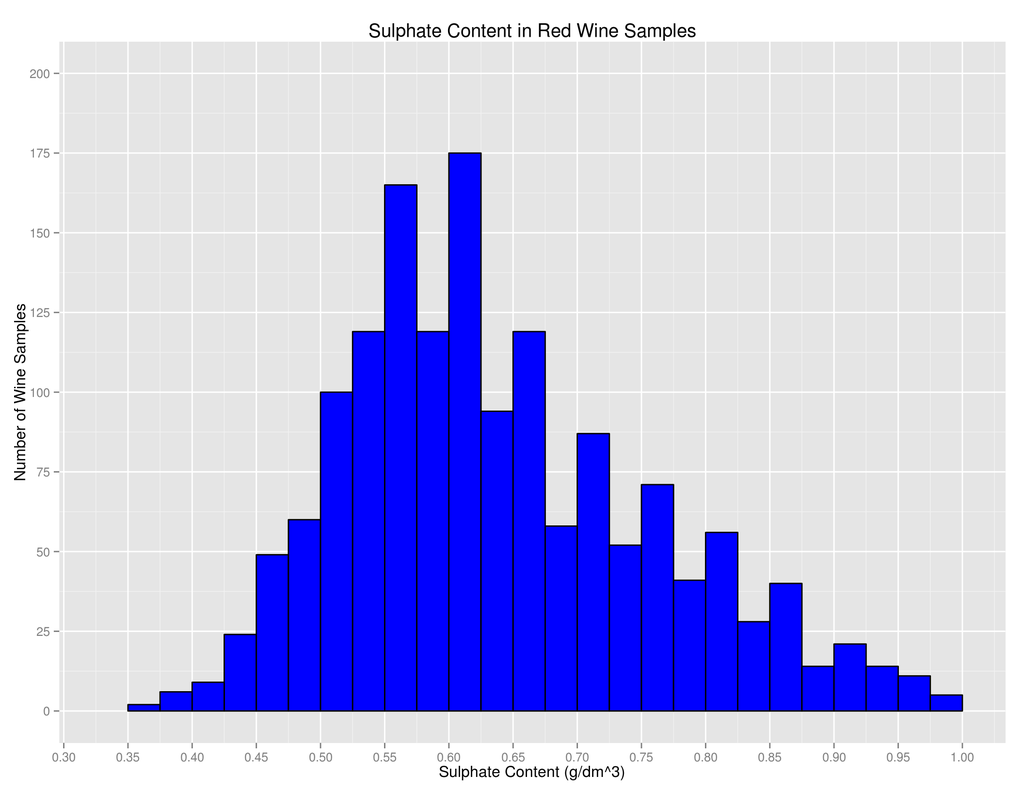

## Plot Two

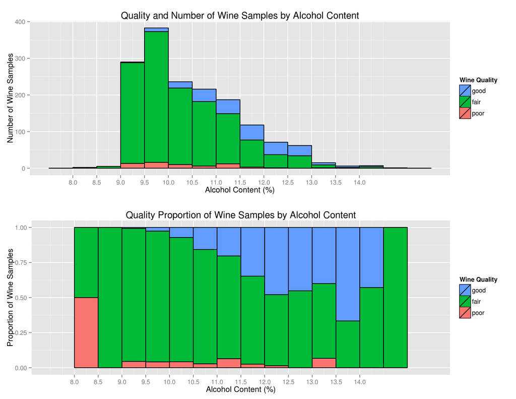

## Plot Three

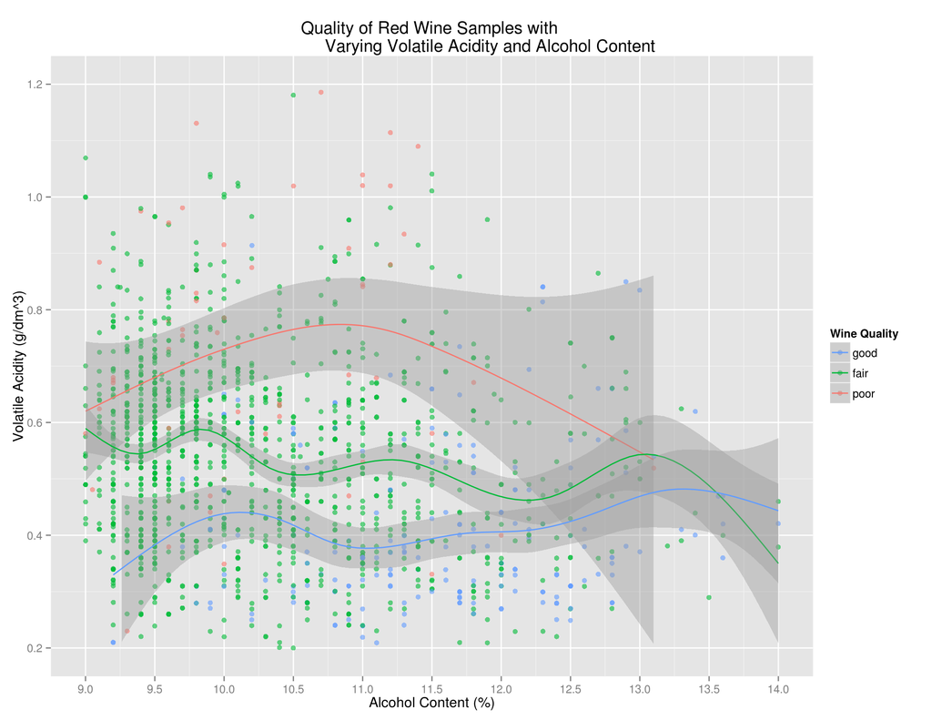

## Description Three

This plot demonstrates how the Quality of the red wine samples varies with different volatile acidity and alcohol percentages. Until roughly 9.25% alcohol, there are no good quality wines and the difference between fair and poor quality wines is not distuinguishable - likely driven by other factors in the wine. Between 9.25% and round 12% alcohol, the volatile acidity seems to play a dominant role in determining the quality of the wine with decreased volatile acidity resulting in better quality wines. After 12% alcohol, this still tends to be the case on average (as shown by the smoothed lines), but the number of samples are also less and so the behaviour in this region is less certain.

# Reflection

The red wine dataset contains physiochemical information on 1599 red wine samples of the Portuguese “Vinho Verde” wine. All of the properties are physiochemical except for the “Quality” property which was rated on a scale from 1 - 10 by wine experts.

I began by using GGAlly to determine the five physiochemical properties that had the greatest correlation with quality. After this, I analyzed each of the five variables individually along with a variable I created called free_ratio, which is the ratio of free sulfur dioxide to total sulfur dioxide. After understanding the distribution of the individual variables, I performed bivariate analyses on the variables to understand how the distributions of each of the variables related to the quality of the wines. After determining which of the variables were still pertinent to the quality outcome, I performed multivariate analyses on these variables to determine optimal value ranges of each of these variables to improve the wine quality for alcohol ranges of 9% to 11%.

One of the difficulties I found with this dataset was that even though there are stronger correlations with quality in some variables than others, no single variable has a very strong correlation with the quality of the wine. This is most likely inherent in the ambiguity and personal preference in wine tasting, but is also likely due to the multivariate complexity that goes into the flavour profile of a good wine. I tried to alleviate some of the taster bias in this dataset by narrowing the wines quality into three bins of “good”, “fair”, and “poor” quality. Even after this modification, I was surprised by how drastically the chemical properties of a “good” wine can be for the same variety of grape.

I created a linear model using the variables of alcohol, volatile acidity, citric acid, sulphates, and the free ratio. Even though this linear model used the most correlated physiochemical properties to assess quality, it was still only able to account for 34% of the variance in quality across all samples. One possibility for the lack of comprehensiveness is that only using five properties is an oversimplification of the properties of wine. Another is that the ratings used by tasters may differ completely due to their personal preferences and the use of a 1 - 10 scale requires a lot of subjective judgement. If I were to perform further work on this dataset, I would be interested to see if a better model could be created using a greater number of variables, along with further transformations of both the quality and physiochemical variables. As well, it would be interesting to look at a dataset that contained a variety of different types of wines, and a greater number of wine tasters.